# Coursera practical machine learning project

Edgar Ekure

June 16, 2017

# BACKGROUND

In this age of big data, collecting large amounts of data relating to how people engage in exercises has become easy and convenient. Devices such as Jawbone Up, Nike FuelBand, and Fitbit have been used to collect a large amount of data about personal activities. Generally, most people are more interested in the quantification of a particular activity than how well they perform such activities.

## GOAL OF STUDY

The goal of this study was to use data from accelerometers on the belt, forearm, arm, and dumbell of 6 participants, and predict how the activities were performed, using any of the predictor variables to predict the outcome measure “classe”.

## DATA

The data used were sourced from the website http://groupware.les.inf.puc-rio.br/har (see the section on the Weight Lifting Exercise Dataset).

The training dataset can be seen here:

https://d396qusza40orc.cloudfront.net/predmachlearn/pml-training.csv

The testing dataset can be seen here:

https://d396qusza40orc.cloudfront.net/predmachlearn/pml-testing.csv

The libraries below are needed to excutive the analyses of this study.

```r
library(caret)
```

```r
library(ggthemes)
library(gridExtra)
library(ggplot2)
library(randomForest)
library(grid)
library(rpart)
library(rattle)
library(rpart.plot)
library(RColorBrewer)
```

The two next chunks of codes downloads the data, reads the CSV files, and removes missing values (NA)

```r
set.seed(46)

url_train <- "http://d396qusza40orc.cloudfront.net/predmachlearn/pml-training.csv"
url_test <- "http://d396qusza40orc.cloudfront.net/predmachlearn/pml-testing.csv"

training <- read.csv(url(url_train), na.strings=c("NA","#DIV/0!",""))
testing <- read.csv(url(url_test), na.strings=c("NA","#DIV/0!",""))
```

```r
training <- training[, colSums(is.na(training)) == 0]
testing <- testing[, colSums(is.na(testing)) == 0]
```

Columns 1 through 7 were removed in the code below because they were variables not important to the prediction.

```r
train_sel <- training[, -c(1:7)]
test_sel <- testing[, -c(1:7)]
```

Partitioning the data into 60% training and 40% testing datasets

```r
train1 <- createDataPartition(train_sel$classe, p = 0.6, list = FALSE)
train2 <- train_sel[train1, ]
test2 <- train_sel[-train1, ]
```

Random Forest was used to model the data

```r
set.seed(48)
model1 <- randomForest(classe ~ ., data = train2, ntrees = 500, Importance = TRUE)
print(model1)
```

```
##
## Call:
##  randomForest(formula = classe ~ ., data = train2, ntrees = 500,      Importance = TRUE)
##                Type of random forest: classification
##                      Number of trees: 500
## No. of variables tried at each split: 7
##
##         OOB estimate of  error rate: 0.66%
## Confusion matrix:
##      A    B    C    D    E class.error
## A 3341    3    3    1    0 0.002090800
## B   15 2259    5    0    0 0.008775779
## C    0    9 2041    4    0 0.006329114
## D    0    0   26 1902    2 0.014507772
## E    0    0    2    8 2155 0.004618938
```

The out of bag error was very small, the confusion matrix showed good predictions with minimal misclassifications.

Next error rate was modeled as a function of the number of trees

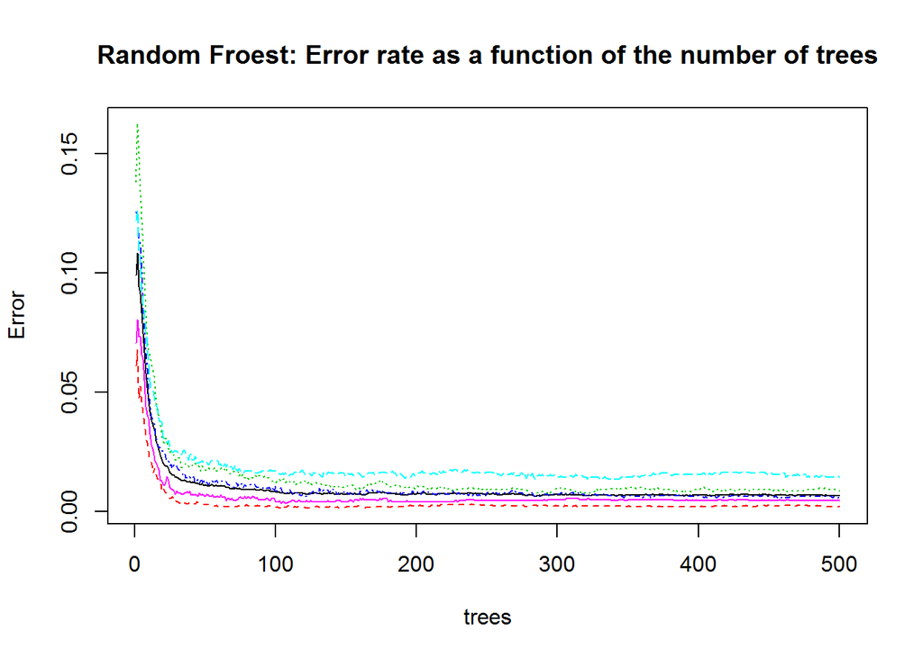

```r
plot(model1, main = "Random Froest: Error rate as a function of the number of trees")
```

The error rate from the above plot asymptotes to the lowest error rate at about 100 trees.

Predicting test dataset

```r
prediction1 <- predict(model1, newdata = test2)
confusionMatrix(prediction1, test2$classe)
```

```
## Confusion Matrix and Statistics
##
##           Reference
## Prediction    A    B    C    D    E
##          A 2231    5    0    0    0
##          B    0 1508    7    0    0
##          C    0    5 1360   15    0
##          D    0    0    1 1270    6
##          E    1    0    0    1 1436
##
## Overall Statistics
##
##                Accuracy : 0.9948
##                  95% CI : (0.9929, 0.9962)
##     No Information Rate : 0.2845
##     P-Value [Acc > NIR] : < 2.2e-16
##
##                   Kappa : 0.9934
##  Mcnemar's Test P-Value : NA
##
## Statistics by Class:
##
##                      Class: A Class: B Class: C Class: D Class: E
## Sensitivity            0.9996   0.9934   0.9942   0.9876   0.9958
## Specificity            0.9991   0.9989   0.9969   0.9989   0.9997
## Pos Pred Value         0.9978   0.9954   0.9855   0.9945   0.9986
## Neg Pred Value         0.9998   0.9984   0.9988   0.9976   0.9991
## Prevalence             0.2845   0.1935   0.1744   0.1639   0.1838
## Detection Rate         0.2843   0.1922   0.1733   0.1619   0.1830
## Detection Prevalence   0.2850   0.1931   0.1759   0.1628   0.1833
## Balanced Accuracy      0.9993   0.9962   0.9955   0.9932   0.9978
```

The accuracy of the prediction was high, 99.48%. Sensitivity and specificity were also very in the high ninety percents.

The second model was performed using rpart

```r
set.seed(48)
model2 <- rpart(classe ~ ., data = train2, method = "class")
printcp(model2)
```

```
##
## Classification tree:
## rpart(formula = classe ~ ., data = train2, method = "class")
##
## Variables actually used in tree construction:
##  [1] accel_dumbbell_y     accel_dumbbell_z     accel_forearm_x
##  [4] magnet_belt_z        magnet_dumbbell_y    magnet_dumbbell_z
##  [7] magnet_forearm_z     pitch_belt           pitch_forearm
## [10] roll_belt            roll_dumbbell        roll_forearm
## [13] total_accel_dumbbell yaw_belt             yaw_forearm
##
## Root node error: 8428/11776 = 0.71569
##
## n= 11776
##
##          CP nsplit rel error  xerror      xstd
## 1  0.116516      0   1.00000 1.00000 0.0058081
## 2  0.050486      1   0.88348 0.88348 0.0062084
## 3  0.038443      4   0.72010 0.78631 0.0063870
## 4  0.031680      5   0.68166 0.66315 0.0064296
## 5  0.031443      6   0.64998 0.62874 0.0064056
## 6  0.021713      7   0.61853 0.59753 0.0063701
## 7  0.018510     12   0.49739 0.54948 0.0062895
## 8  0.018154     13   0.47888 0.49407 0.0061558
## 9  0.013526     14   0.46073 0.46025 0.0060516
## 10 0.010797     15   0.44720 0.42845 0.0059370
## 11 0.010204     16   0.43640 0.39654 0.0058049
## 12 0.010145     17   0.42620 0.39143 0.0057821
## 13 0.010026     22   0.36272 0.38740 0.0057638
## 14 0.010000     24   0.34267 0.38016 0.0057301
```

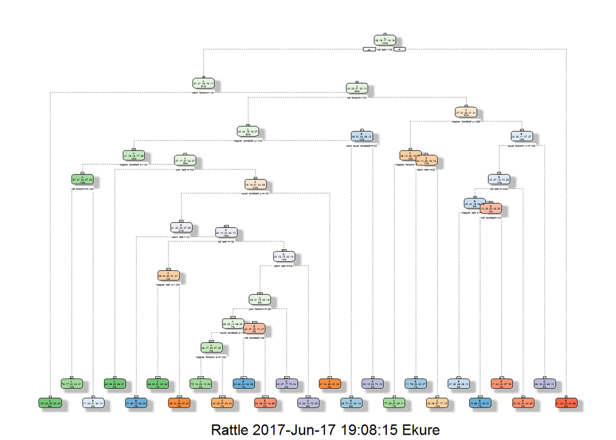

```r
fancyRpartPlot(model2)
```

Fancy plot of the decision tree generated using rpart, rpart.plot, and rattle libraries

Below is the prediction based on the second model

```r
prediction2 <- predict(model2, test2, type = "class")
confusionMatrix(prediction2, test2$classe)
```

```
## Confusion Matrix and Statistics
##
##           Reference
## Prediction    A    B    C    D    E
##          A 1989  227   27   75   20
##          B   85 1000  152  136  171
##          C   67  151 1107  201  169
##          D   63  112   82  797   86
##          E   28   28    0   77  996
##
## Overall Statistics
##
##                Accuracy : 0.7506
##                  95% CI : (0.7408, 0.7601)
##     No Information Rate : 0.2845
##     P-Value [Acc > NIR] : < 2.2e-16
##
##                   Kappa : 0.684
##  Mcnemar's Test P-Value : < 2.2e-16
##
## Statistics by Class:
##
##                      Class: A Class: B Class: C Class: D Class: E
## Sensitivity            0.8911   0.6588   0.8092   0.6198   0.6907
## Specificity            0.9378   0.9140   0.9092   0.9477   0.9792
## Pos Pred Value         0.8507   0.6477   0.6531   0.6991   0.8822
## Neg Pred Value         0.9559   0.9178   0.9576   0.9271   0.9336
## Prevalence             0.2845   0.1935   0.1744   0.1639   0.1838
## Detection Rate         0.2535   0.1275   0.1411   0.1016   0.1269
## Detection Prevalence   0.2980   0.1968   0.2160   0.1453   0.1439
## Balanced Accuracy      0.9145   0.7864   0.8592   0.7837   0.8350
```